# Ass2_1

Assignment2

Question 1 , choose the radius to be 𝑅 = 1

```python
import random
import math
import numpy as np
import matplotlib.pyplot as plt
```

1.a)First implement this using the rejection method by thinking of the circle being enveloped by a square. Generate 2000 points (𝑥, 𝑦) and plot them.

```python
x = []
y = []
```

```python
# initialize the variable
i = 1
n = 2000
random.seed(11)

# while loop from i = 1 to 2000
while i <= 2000:
    a=random.uniform(-1,1)
    b=random.uniform(-1,1)
    if (a*a+b*b)<1 :
        x.append(a)
        y.append(b)
        i = i + 1
```

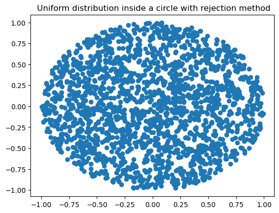

```python
# Generate 2000 points with rejection method, and plot them
plt.figure(1)
plt.plot(x, y,'o')
plt.title(" Uniform distribution inside a circle with rejection method")
plt.show()
```

1.b)You want to make the simulation computationally more effective and not to reject any points, so you generate random points inside the circle by using polar coordinates, 𝑥 = 𝑟 cos(2𝜋𝜃) , 𝑦 = 𝑟 sin(2𝜋𝜃), and drawing 𝑟 and 𝜃 from uniform distributions. Generate 2000 points (𝑥, 𝑦) and plot them. Explain the outcome and the reason for it

```python
x = []
y = []
```

generate random points inside the circle by using polar coordinates

```python
# initialize the variable
i = 1
n = 2000
random.seed(11)
#Generate 2000 random points inside the circle by using polar coordinates
# while loop from i = 1 to 2000
while i <= 2000:
    r=random.uniform(0,1)
    theta=random.uniform(0,1)
    # 𝑥 = 𝑟 cos(2𝜋𝜃) , 𝑦 = 𝑟 sin(2𝜋𝜃)
    x.append(𝑟*math.cos(2*math.pi*theta))
    y.append(𝑟*math.sin(2*math.pi*theta))
    i = i + 1
```

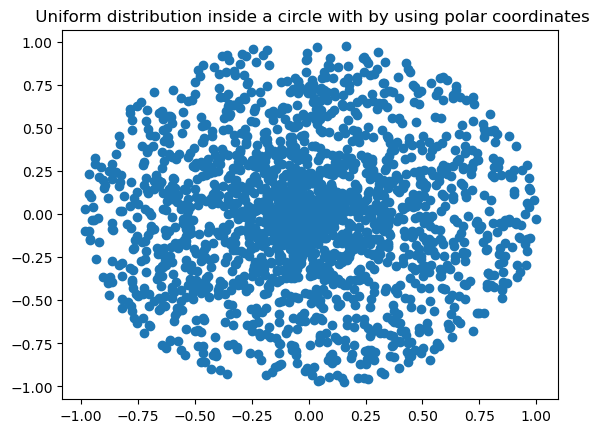

```python
# Generate 2000 random points inside the circle by using polar coordinates, and plot them
plt.plot(x, y,'o')
plt.title(" Uniform distribution inside a circle with by using polar coordinates")
plt.show()
```

1.c) Simulate the circular uniform distribution by the inverse distribution method. Generate (x, y) from polar coordinates again drawing theta from uniform distribution but applying a proper transformation for the radius r ∈ (0, R)

[figure not shown]

```python
x = []
y = []
```

```python
# initialize the variable
i = 1
n = 2000
random.seed(11)
#Generate 2000 random points inside the circle by using polar coordinates
# while loop from i = 1 to 2000
while i <= 2000:
    r=math.sqrt(random.uniform(0,1)) # choose the radius to be 𝑅 = 1
    theta=2*math.pi*random.uniform(0,1)
    # 𝑥 = 𝑟 cos(𝜃) , 𝑦 = 𝑟 sin(𝜃)
    x.append(𝑟*math.cos(theta))
    y.append(𝑟*math.sin(theta))
    i = i + 1
```

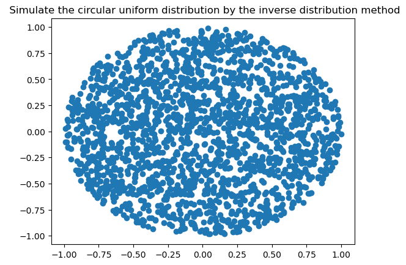

```python
# Generate 2000 random points inside the circle by using polar coordinates, and plot them
plt.plot(x, y,'o')
plt.title(" Simulate the circular uniform distribution by the inverse distribution method")
plt.show()
```

1. d) Compare the outcomes of b) and c). Explain the difference.

   Answer: choose the radius to be 𝑅 = 1 b) outcomes are shown more in the center of the circle and C) outcome are more uniformed in the whole cirle area.  
   The reason for b) outcomes is due to sampled point has uniform possibility in radius to be value (0,1) and also uniformed value the the theta around the circle (0,2*PI), so when it is closed to the center of the circle it looks likehas more density of the sample points.